# IFX_2022 - Project - PAM-B

PSS RFS DR RF PTE PRE

2025-07-03

##### IFX_2022 - Project - PAM-B

# 1 Overview

## 1.1 Flow_chart

### 1.1.1 Flow_chart.png

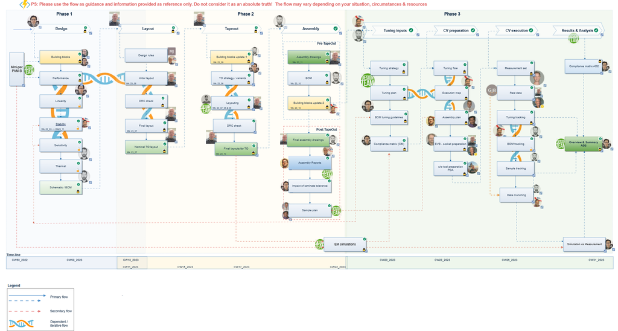

00_Flow_chart.png

### 1.1.2 Roles.png

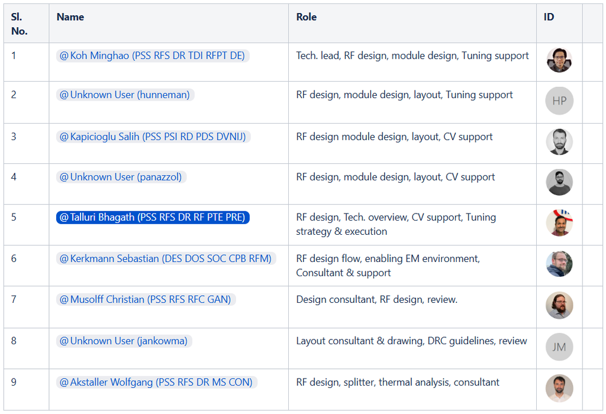

01_Roles.png

### 1.1.3 Responsibility_Design.png

[figure not shown]

02_Responsibility_Design.png

### 1.1.4 Responsibility_LO_TO_AD_BOM.png

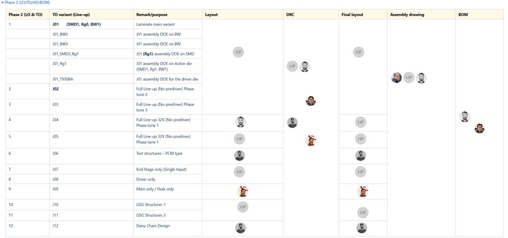

03_Responsibility_LO_TO_AD_BOM.png

## 1.2 Summary

### 1.2.1 PAM_B_Overview_AD2_summary_29-8-2023.pdf

[figure not shown]

# 2 Mini-pac_PAM_B

## 2.1 Introduction

### 2.1.1 Motivation.pdf

[figure not shown]

### 2.1.2 Line-up_calculation.png

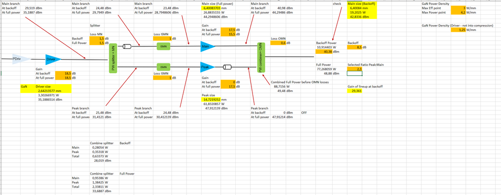

02_Line-up_calculation.png

### 2.1.3 Die_selection.pdf

[figure not shown]

## 2.2 Design

### 2.2.1 Stack_up_Laminate.png

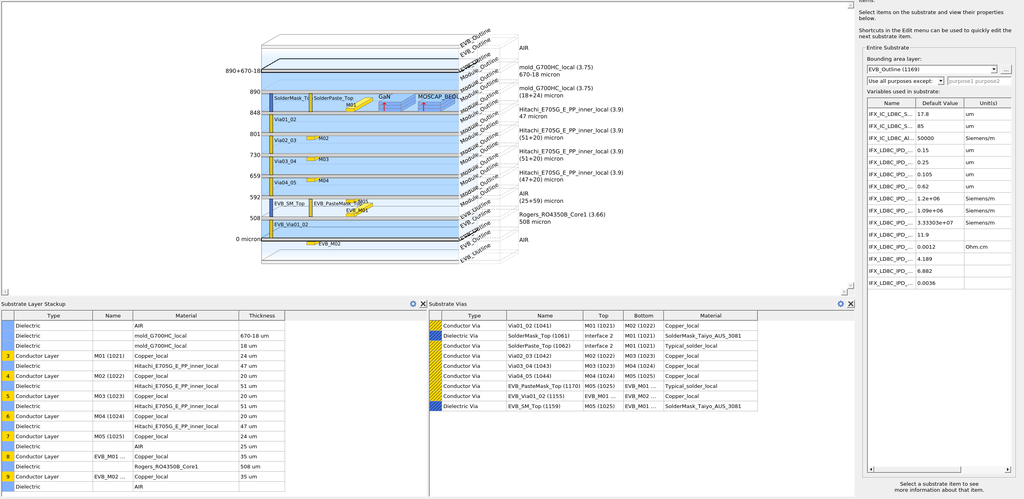

01_Stack_up_Laminate.png

### 2.2.2 Stack_up_Moscap.png

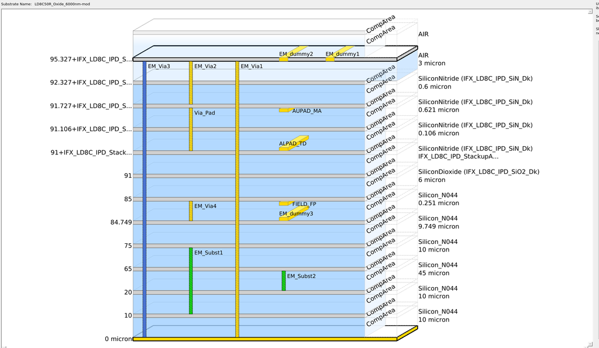

02_Stack_up_Moscap.png

### 2.2.3 PAM_B 2_88mm Driver.pdf

[figure not shown]

### 2.2.4 P49_Main_Transistor.pdf

[figure not shown]

### 2.2.5 P41_Peak_Transistor.pdf

[figure not shown]

## 2.3 Assembly

### 2.3.1 Planning.pdf

[figure not shown]

### 2.3.2 Assembly Design review.pdf

[figure not shown]

### 2.3.3 Assembly_drawings

#### 2.3.3.1 PAMB_PD3pre_lib__P41_R9505A_Direct_DOE1_BW1a2a.pdf

[figure not shown]

#### 2.3.3.2 PAMB_PD3pre_lib__P41_R9505A_N9501B_Std_3p21pF_DOE2_BW3a4a5a.pdf

[figure not shown]

#### 2.3.3.3 PAMB_PD3pre_lib__P41_R9505A_N9501B_V3_2p57pF_DOE3_BW3a6a5a.pdf

[figure not shown]

#### 2.3.3.4 PAMB_PD3pre_lib__P41_R9505A_N9501B_V5_2p23pF_DOE4_BW3a7a5a.pdf

[figure not shown]

#### 2.3.3.5 PAMB_PD3pre_lib__P44_R9505A_N9501B_V8_1p89_BW3a4a5a.pdf

[figure not shown]

#### 2.3.3.6 PAMB_PD3pre_lib__P44_T9508A_N9501B_V8_1p89_BW3a4a5a.pdf

[figure not shown]

#### 2.3.3.7 PAMB_PD3pre_lib__P49_R9512_A_10pF22_N9501B_V4_BW1o2o3o.pdf

[figure not shown]

#### 2.3.3.8 PAMB_PD3pre_lib__P49_R9512_A_10pF97_N9501B_V3_BW1o2o3o.pdf

[figure not shown]

#### 2.3.3.9 PAMB_PD3pre_lib__P49_R9512_A_11pF87_N9501B_V2_BW1o2o3o.pdf

[figure not shown]

#### 2.3.3.10 PAMB_PD3pre_lib__P49_R9512_A_8pF09_N9501B_V8_BW1o2o3o.pdf

[figure not shown]

## 2.4 LP_measurements

### 2.4.1 LP_measurement_flow.pdf

[figure not shown]

### 2.4.2 Anteverta

#### 2.4.2.1 LP results run 1 PAM-B minipac T9508.pdf

[figure not shown]

### 2.4.3 FOCUS_VIH

#### 2.4.3.1 LP_measurement_instructions.pdf

[figure not shown]

#### 2.4.3.2 DOE1B_1_A063_Driver_report.pdf

[figure not shown]

#### 2.4.3.3 DOE2B_2_D044_Main_report.pdf

[figure not shown]

#### 2.4.3.4 DOE3B_3_A063_Peak_report.pdf

[figure not shown]

## 2.5 Model_vs_Measurements

### 2.5.1 PAM_B_Run1_Minipac_Sim_vs_Meas_V0.pdf

[figure not shown]

### 2.5.2 Appendix

#### 2.5.2.1 Appendix_Model_vs_measurements.pdf

[figure not shown]

#### 2.5.2.2 Tx_Baseline_Model_library_Manual.pdf

[figure not shown]

## 2.6 Conclusion

### 2.6.1 Conclusion.pdf

[figure not shown]

## 2.7 Next_steps

### 2.7.1 BM evaluation with PAM-B Mini-Pac.pdf

[figure not shown]

# 3 Design

## 3.1 Performance

### 3.1.1 Building_blocks.pdf

[figure not shown]

### 3.1.2 Concept_review.pdf

[figure not shown]

### 3.1.3 Design_review.pdf

[figure not shown]

## 3.2 Linearity

### 3.2.1 FCC_Spec_Discussion.pdf

[figure not shown]

### 3.2.2 Linearity.pdf

[figure not shown]

### 3.2.3 Measurement_method.pdf

[figure not shown]

## 3.3 Stability

### 3.3.1 SS stability STAN_PAM-B_PD3 FLU 11022023.pdf

[figure not shown]

### 3.3.2 Overview

#### 3.3.2.1 Stability analysis.pdf

[figure not shown]

## 3.4 Sensitivity_analysis

### 3.4.1 Summary_sensitivity_analysis.pdf

[figure not shown]

### 3.4.2 PAM-B PD3 Sensitivity Analysis V04.pdf

[figure not shown]

## 3.5 Reliability_analysis

### 3.5.1 PAMB_PD3_Reliability_Analysis_V1p1.pdf

[figure not shown]

## 3.6 Schematic_BOM

### 3.6.1 Initial.pdf

[figure not shown]

### 3.6.2 Final_V2p3.pdf

[figure not shown]

# 4 Layout

## 4.1 PAM LGiT_substrate_design rules.pdf

[figure not shown]

## 4.2 PAM Assy design rules.pdf

[figure not shown]

## 4.3 Layout_preparation.pdf

[figure not shown]

## 4.4 Nominal_Layout.pdf

[figure not shown]

# 5 Tapeout

## 5.1 Building blocks update.pdf

[figure not shown]

## 5.2 TapeOut strategy_ Variants.pdf

[figure not shown]

## 5.3 Layout_and_DRC.pdf

[figure not shown]

## 5.4 Final_layout_TO

### 5.4.1 Final layouts for TO.pdf

[figure not shown]

### 5.4.2 Layout_snapshots.pdf

[figure not shown]

## 5.5 EM_simulations

### 5.5.1 EM_simulation_All_variants.pdf

[figure not shown]

### 5.5.2 EM_simulation_J09.pdf

[figure not shown]

### 5.5.3 Impact_molding_material.pdf

[figure not shown]

### 5.5.4 Impact_dielectric_thickness.pdf

[figure not shown]

# 6 Assembly

## 6.1 Pre_Tape_out

### 6.1.1 Assembly_Drawing_Tracker.pdf

[figure not shown]

### 6.1.2 BOM_tracker.pdf

[figure not shown]

### 6.1.3 Building_blocks_update_2.pdf

[figure not shown]

## 6.2 Post_Tape_out

### 6.2.1 LGit_laminate_assembly_report.pdf

[figure not shown]

### 6.2.2 Dielectric_thickness_simulation.pdf

[figure not shown]

### 6.2.3 Final_AD_overview.pdf

[figure not shown]

### 6.2.4 sample_planning.pdf

[figure not shown]

### 6.2.5 BW_height_measurements.pdf

[figure not shown]

### 6.2.6 Sample_planning

# 7 Tuning_CV

## 7.1 Tuning_inputs

### 7.1.1 Tuning_TO_strategy.pdf

[figure not shown]

### 7.1.2 Tuning_plan_details.png

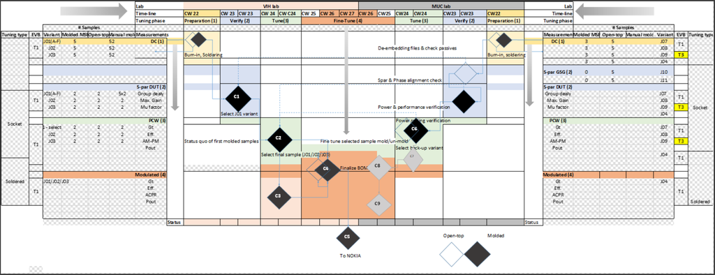

02_Tuning_plan_details.png

### 7.1.3 BOM_tuning_guidelines.pdf

[figure not shown]

### 7.1.4 Compliance_matrix.pdf

[figure not shown]

## 7.2 CV_preparation

### 7.2.1 Tuning_flow.pdf

[figure not shown]

### 7.2.2 Actual_execution_plan.png

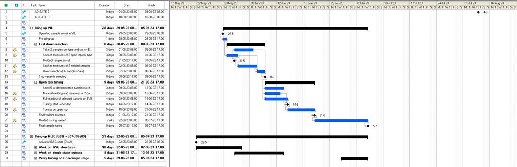

02_Actual_execution_plan.png

### 7.2.3 Logistic_Assembly_plan.pdf

[figure not shown]

### 7.2.4 EVB_socket_preparation.pdf

[figure not shown]

### 7.2.5 Final_delivery_schedule.pdf

[figure not shown]

### 7.2.6 Px_dB calculation method.pdf

[figure not shown]

## 7.3 CV_execution

### 7.3.1 Measurement set.pdf

[figure not shown]

### 7.3.2 Tuning tracking.pdf

[figure not shown]

### 7.3.3 Raw data_crunching.pdf

[figure not shown]

### 7.3.4 BOM_tracking

#### 7.3.4.1 Full_variants.pdf

[figure not shown]

#### 7.3.4.2 NIJ_tuning.pdf

[figure not shown]

#### 7.3.4.3 J01F.pdf

[figure not shown]

#### 7.3.4.4 J05_32V.pdf

[figure not shown]

#### 7.3.4.5 J07_Final_stage.pdf

[figure not shown]

#### 7.3.4.6 J08_Driver.pdf

[figure not shown]

#### 7.3.4.7 J09_Main_Peak.pdf

[figure not shown]

### 7.3.5 Sample_tracking

#### 7.3.5.1 Tuning_samples.pdf

[figure not shown]

#### 7.3.5.2 AD2_samples.pdf

[figure not shown]

# 8 Results_Analysis

## 8.1 Summary.pdf

[figure not shown]

## 8.2 AD2_Gate

### 8.2.1 J01I_(T48_0102_MSEm_S)_Full_Read_out.pdf

[figure not shown]

### 8.2.2 J01M_(T48_0103_MSEm_S)_Full_Read_out.pdf

[figure not shown]

### 8.2.3 J01M_(T48_0105_MSEm_S)_Full_Readout.pdf

[figure not shown]

### 8.2.4 J01M_J01I_MSEm_T48_Z_sample_selection.pdf

[figure not shown]

### 8.2.5 J01M_T48_0103_MSEm_S_(iDPD_vs_nDPD).pdf

[figure not shown]

### 8.2.6 J01M_T48_0104_MSEm_Z_(iDPD_vs_nDPD).pdf

[figure not shown]

### 8.2.7 LUT_0102_0103.pdf

[figure not shown]

## 8.3 Full_Read_out

### 8.3.1 J01A_(S04_T24_S).pdf

[figure not shown]

### 8.3.2 J01B_(S19_T30_S).pdf

[figure not shown]

### 8.3.3 J01B_(S19_T30_S_Before_After_M).pdf

[figure not shown]

### 8.3.4 J01B_(S19_T30_S_M).pdf

[figure not shown]

### 8.3.5 J01B_S01_T09_M_S.pdf

[figure not shown]

### 8.3.6 J01G_(S07_T48_S_M).pdf

[figure not shown]

### 8.3.7 J01G_(S22_T60_M_S).pdf

[figure not shown]

### 8.3.8 J01M_S03_T76_S_M.pdf

[figure not shown]

### 8.3.9 MSE-J01G_S08_(T47_S_M).pdf

[figure not shown]

## 8.4 GSG_Passives_measurement

### 8.4.1 J06.pdf

[figure not shown]

## 8.5 Delta_quantification

### 8.5.1 Impact_of_socket_solder

#### 8.5.1.1 J01B_S19_T30_Soldered_vs_Znew.pdf

[figure not shown]

#### 8.5.1.2 MSE-J01A_S01_ T00 Paricon(Loadplate_3) vs Zigma.pdf

[figure not shown]

#### 8.5.1.3 MSE-J03_S03_ T00 Zigma vs Soldered.pdf

[figure not shown]

### 8.5.2 Impact_of_mold

## 8.6 Debug_experiments

### 8.6.1 Impact_of_Idq_Optimization

### 8.6.2 Impact_of_temparature

### 8.6.3 Impact_of_Vds

## 8.7 Down_selection

## 8.8 Performance_improvement

### 8.8.1 ACLR_improvement

### 8.8.2 Driver_BW_improvement

### 8.8.3 Driver_Gain_improvement

### 8.8.4 Gain_dip_correction

#### 8.8.4.1 Gain-dip correction_ *choice 20 pF GRM 100V–T09–*-v24-20250623_145917.pdf

[figure not shown]

### 8.8.5 PAE_Ppeak_improvement

### 8.8.6 S22_Off-state_improvement

### 8.8.7 Wideband_gain_flateness_improvement

## 8.9 Mile-stone_comparisons

# 9 Sim_vs_Meas

## 9.1 PAM_B_Simulation_vs_Measurement.pdf

[figure not shown]

# 10 Poster

## 10.1 PAM_B_PD3_Poster.png

[figure not shown]

01_PAM_B_PD3_Poster.png